# Coursera Finance Specialisation (U Michigan) M2 – Risk and Return Week 1

Joe Nguyen

27 November 2015

## 1.1 Financing: Bond and Stocks

| Assets | Liabilities |
| --- | --- |
| **Real** assets | Equity / shares / stocks |
|  | Debt / bonds |

## 1.2 Zero-Coupon Government Bonds

### Bonds

- A bond binds the borrower to the lender in a contract
- e.g. a loan
- Contract: entity (e.g. you) between entity (e.g. bank)

### Zero-Coupon (or Discount) Bonds

- This bond has only one payment, the face value, at maturity
- e.g. treasury bill or strip in the U.S.
- The price of a discount bond is `PV(P, r, n)`

#### Discount Bond: Example

A zero-coupon bond pays $1000 in exactly one year. What is the price of value (price of the bond) today if the interest rate on similar bonds is 2%?

```r
PV(1000, 0.02, 1)
```

```
## [1] 980.3922
```

#### Yield to Maturity: Example

What is the YTM of a 10-year zero-coupon bond with a face value of $1000 and a current price of $744.09?

```r
YTM(1000, 744.09, 10)
```

```
## [1] 0.03000054
```

```r
# or using IRR
cVec <- rep(0,10); cVec[10] <- 1000
IRR(744.09, cVec)
```

```
## [1] 0.02999536
```

#### Yield to Maturity: Example 2

What is YTM if compounding interval is 6 months?

```r
YTM(1000, 744.09, 20)
```

```
## [1] 0.01488942
```

```r
# or using IRR
n <- 20
cVec <- rep(0,n); cVec[n] <- 1000
IRR(744.09, cVec)
```

```
## [1] 0.01487663
```

## 1.3 Government Coupon Bonds

#### Coupon Bonds: Example

Suppose a government bond has a 6% coupon, a face value of $1000, and 10 years to maturity. What is the price of this bond given that similar bonds yield an annual return of (4, 6, 8)%?

Intepretation: - Need to assume compounding interval is 6 months (gov. bond), - “6% coupon” is a value (paid by gov. to you) every interval. The coupon price $C$ is: $coupon \ percent = \frac{C}{fv}$

$6\% = \frac{C}{1000}$ So $C = \$60$ per year, which means $C = \$30$ per interval. Now, C is paid every period for 20 periods and the face value ($1000) is also paid at maturity. - “What is price of this bond”: How much is the PV of this bond, where you pay the face value ($1000) for it now?

```r
fv <- 1000
n <- 10 * halfsPerYear
r <- c(4,6,8,10,15,20) / 100 / halfsPerYear
c <- r[2] * fv
pvC <- annuity_pv(c, r, n)
pvFv <- PV(fv, r, n)
pvTot <- pvC + pvFv
rbind(pvC, pvFv, pvTot)
```

```
##            [,1]      [,2]     [,3]     [,4]     [,5]     [,6]
## pvC    490.5430  446.3242 407.7098 373.8663 305.8347 255.4069
## pvFv   672.9713  553.6758 456.3869 376.8895 235.4131 148.6436
## pvTot 1163.5143 1000.0000 864.0967 750.7558 541.2479 404.0505
```

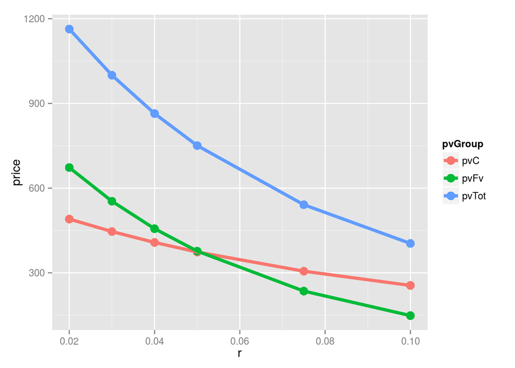

```r
# Plot
nr <- length(r)
pvGroup <- factor(rep(1:3, each = nr), labels = c("pvC", "pvFv", "pvTot"))
pvDf <- data.frame(r = rep(r, times = 3), price = c(pvC, pvFv, pvTot), pvGroup)
library(ggplot2)
ggplot(data = pvDf, aes(r, price, group = pvGroup, col = pvGroup)) +
    geom_point(size = 4) + geom_line(lwd = 1.5)
```

So, if market value (interest rate $r$) is same as coupon rate, we buy bond at *face value* or at par. If $r < c_{rate}$, the bond is attractive to investors, who will purchase these bonds and bid the price up to a **premium** until $c_{rate} = r$. If interest rates are high $r > c_{rate}$, the bond is no longer attractive and the bond price will decrease, selling at a **discount** until $c_{rate} = r$.

Note however, that these prices adjust the bond face value according to $r$ and $n$ so that the bond is **fairly priced** according to TVM. There is no profit or loss.

## 1.5 Sources of Risk in Bonds

### Government Bonds

#### Interest rate risk – two types:

1. Price risk (PR)
2. Coupon reinvestment risk (CRR)

### Corporate Bonds and Default Risk

- Corporate bonds almost always pay coupons
- Like government bonds, they are subject to interest rate risk
- But they are also subject to **default risk**